# Welcome to Safran Lab 2

Every day, more than 80,000 commercial flights take place around the world, operated by hundreds of airlines. For all aircraft take-off weight exceeding 27 tons, a regulatory constraint requires companies to systematically record and analyse all flight data, for the purpose of improving the safety of flights. Flight Data Monitoring strives to detect and prioritize deviations from standards set by the aircraft manufacturers, the authorities of civil aviation in the country, or even companies themselves. Such deviations, called events, are used to populate a database that enables companies to identify and monitor the risks inherent to these operations.

This notebook is designed to let you manipulate real aeronautical data, provided by the Safran Group. It is divided in two parts: the first part deals with data exploration, data visualization, the use case, analysis of distributions and simple linear models to predict the fuel consumption of a flight. The second part deals with more complex models, optimization of parameters, interpretation of the results, and models to predict the fuel consumption of each flight phase and finally conclude by the objective of giving pieces of advice to the pilot so that he optimizes the consumption of fuel the next time.

Load the cell below for overall set up

```python
# set up
BASE_DIR = "../safran/TP2/data/"

import time

import glob

import matplotlib as mpl
import matplotlib.pylab as plt
%matplotlib inline
import matplotlib.dates as mdates
mpl.rcParams['axes.grid'] = True

import numpy as np
import scipy as sp
import pandas as pd

pd.options.display.max_columns = 23

from datetime import datetime

from sklearn import tree, linear_model, model_selection, preprocessing, decomposition
from sklearn.metrics import mean_squared_error


# read_pickle
dfs = []
files = glob.glob(BASE_DIR + "flights/*.pkl")

p = 0
for idx, file in enumerate(files):
    if idx % int(len(files) / 10) == 0:
        print(str(p * 10) + "%: [" + "#" * p + " " * (10 - p) + "]", end="\r")
        p += 1
    dfs.append(pd.read_pickle(file))


# load global values data, Summarising global values in a dataframe

file_features_df = BASE_DIR + "features_df.pkl"
file_output_df = BASE_DIR + "output_df.pkl"

features_df = pd.read_pickle(file_features_df)
output_df = pd.read_pickle(file_output_df)

# flight_phases

flight_phases = ['APPROACH', 'CLIMB', 'CRUISE', 'DESCENT', 'ENG START', 'FINAL APP',
                 'FLARE', 'INIT CLIMB', 'LANDING', 'TAKE OFF', 'TAXI IN', 'TAXI OUT', 'TOUCH N GO',
                 'LVL CHANGE', 'GO AROUND']
```

```
100%: [##########]
```

# 1 Know & understand the data

**Context**

You are provided with nearly 3000 flights operating different routes.

Each flight data is a collection of time series resumed in a dataframe, the sample rate is 1Hz, the columns variables are described in the schema below:

**Schema**

| VAR | DESCRIPTION | UNIT |
| --- | --- | --- |
| ORIGIN | Flight departure airport | NA |
| RUNWAY_TO | Flight origin runway | NA |
| DESTINATION | Flight arrival airport | NA |
| RUNWAY_LD | Flight destination runway | NA |
| DATE_HF | High rate date computation | %d/%m/%y (UTC) |
| TIME_HF | High rate time computation | %H:%M:%S (UTC) |
| FLIGHT_PHASE | Current flight-phase | NA |
| ALT_STD_C | Standard altitude corrected | feet |
| HEAD_MAG | Magnetic heading | deg |
| IAS_C | Indicated air speed corrected | knot |
| RALTC | Radio altitude computed from different sources | feet |
| PITCH_C | Pitch attitude corrected | deg |
| ROLL_C | Bank angle corrected | deg |
| FOB | Fuel on board | kg |
| TORQ1_C | Torque corrected (engine 1) | % |
| TORQ2_C | Torque corrected (engine 2) | % |
| NH1_C | NH corrected (engine 1) | % |
| NH2_C | NH corrected (engine 2) | % |
| NL1 | NL Left from frequency input | % |
| NL2 | NL Right from frequency input (NL2) | % |
| GW_C | Gross weight corrected | kg |

Here are some links to get expertise on some variables:

- [torque](http://www.experimentalaircraft.info/articles/aircraft-engine-performance-1.php)
- [aicraft fuel consumption](https://en.wikipedia.org/wiki/Fuel_economy_in_aircraft#Airline_fuel_efficiency)
- [about FOB and fuel flow](http://www.experimentalaircraft.info/articles/aircraft-engine-instruments-1.php)

## Question 1.1

- What variables are categorical?
- What variables are numerical?

```python
# Your code goes here
features_df.head(5)
```

|  | DATE_HF | ORIGIN | DESTINATION | RUNWAY_TO | RUNWAY_LD | MAX_FOB | MAX_GW | TIME_APPROACH | TIME_CLIMB | TIME_CRUISE | TIME_DESCENT | TIME_ENG START | TIME_FINAL APP | TIME_FLARE | TIME_GO AROUND | TIME_INIT CLIMB | TIME_LANDING | TIME_LVL CHANGE | TIME_TAKE OFF | TIME_TAXI IN | TIME_TAXI OUT | TIME_TOUCH N GO | TIME_TOTAL |
| --- | --- | --- | --- | --- | --- | --- | --- | --- | --- | --- | --- | --- | --- | --- | --- | --- | --- | --- | --- | --- | --- | --- | --- |
| 0 | 03/12/15 | ARPT0 | ARPT1 | 08 | 26 | 2820 | 20620.0 | 106 | 857 | 1123 | 762 | 705 | 203 | 12 | 0 | 49 | 36 | 0 | 26 | 222 | 295 | 0 | 4396 |
| 1 | 03/12/15 | ARPT0 | ARPT1 | 08 | 26 | 2752 | 18480.0 | 219 | 1129 | 649 | 933 | 174 | 151 | 7 | 0 | 39 | 53 | 0 | 22 | 219 | 225 | 0 | 3820 |
| 2 | 22/06/15 | ARPT0 | ARPT3 | 24 | 28 | 2026 | 17780.0 | 152 | 1139 | 2418 | 366 | 354 | 188 | 10 | 0 | 47 | 36 | 323 | 23 | 238 | 215 | 0 | 5509 |
| 3 | 10/08/15 | ARPT0 | ARPT3 | 08 | 28 | 1930 | 18300.0 | 32 | 749 | 2676 | 619 | 249 | 243 | 9 | 0 | 34 | 32 | 0 | 21 | 217 | 182 | 0 | 5063 |
| 4 | 21/08/16 | ARPT0 | ARPT4 | 20 | 33 | 2054 | 21540.0 | 62 | 1038 | 1040 | 1210 | 302 | 161 | 5 | 0 | 34 | 24 | 0 | 27 | 506 | 1016 | 0 | 5425 |

## Visualize all time series for one flight

Let's visualize all the numerical time series for one flight, for example `dfs[0]`, to have a sense of how the time series vary.

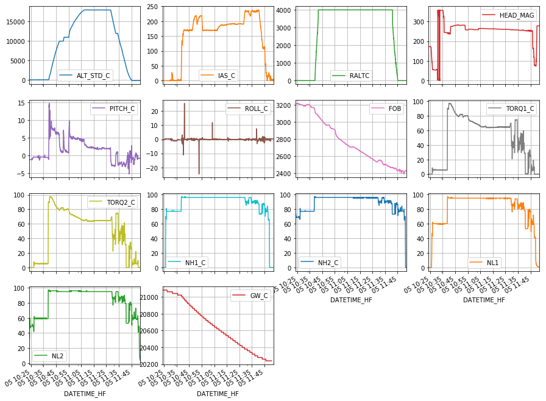

```python
# Give an alias to dfs[0] for convenience
df = dfs[0]

df.plot(kind="line", subplots=True, layout=(4, 4), figsize=(15, 12));
```

## Question 1.2

Comment this visualization of FOB for several flights.

- Is there a pattern?
- Do you notice anything strange?

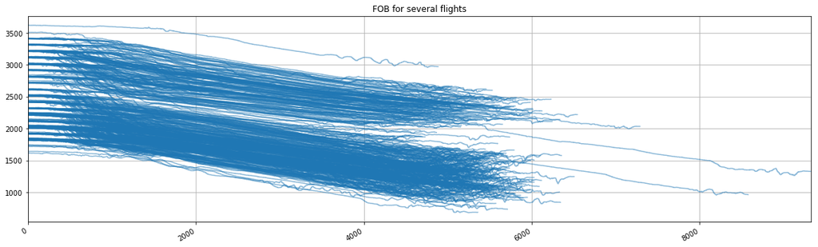

```python
# Create a figure and one subplot
fig, ax = plt.subplots(figsize=(20, 6))

for df in dfs[:500]:
    df.FOB.plot(use_index=False, color="C0", ax=ax, title="FOB for several flights", alpha=0.5)
```

** Answer **  
There is an obvious pattern in fuel consumption during the flight: at first, in the take-off phase the decrease of fuel is not significant. When the decrease is more abrupt we are in the flight phase. At the end (landing) the decreases stabilizes at a variation almost like in the take-off phase. We can see two blobs, which is strange, because it shows that the consumption of fuel is not regular, sometimes aircrafts consume more and sometimes less.

## About FLIGHT_PHASE column

Observe how ALT_STD_C varies for each phase

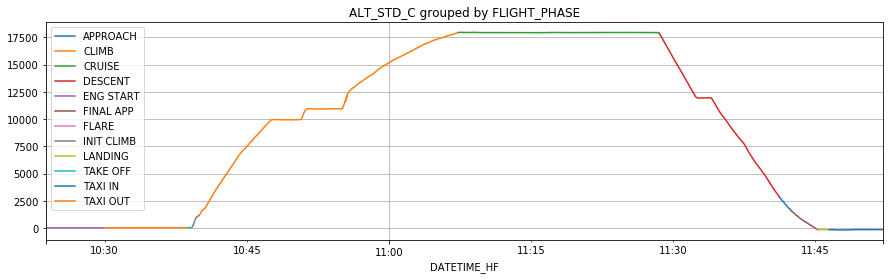

```python
# Create a figure and one subplot
fig, ax = plt.subplots(figsize=(15, 4))

# Give an alias to dfs[0]
df = dfs[0]

df.groupby("FLIGHT_PHASE").ALT_STD_C.plot(title="ALT_STD_C grouped by FLIGHT_PHASE", ax=ax);
ax.legend()
```

**Typical chronology of cruise phases:**

```
- ENG START
- TAXI OUT
- TAKE OFF
- INIT CLIMB
- CLIMB
- CRUISE
- DESCENT
- APPROACH
- FINAL APP
- FLARE
- LANDING
- TAXI IN
```

**Phases that exist only for some flights:**

```
- LVL CHANGE
- GO AROUND
- TOUCH N GO
```

## About DELTA_FOB

- `MAX_FOB`: FOB at the beginning of the flight
- `MIN_FOB`: FOB at the end of the flight
- `DELTA_FOB`: `MAX_FOB` - `MIN_FOB` the amount of fuel consumed during the whole flight

[figure not shown]

```python
# Create a figure and one subplot
fig, ax = plt.subplots(figsize=(15, 4))

# Give an alias to dfs[0]
df = dfs[0]

df.FOB.plot(title="FOB")
plt.axhline(df.FOB.max(), color="C1")
plt.axhline(df.FOB.min(), color="C1")
plt.axvline(df.FOB.index[-200], linestyle=":", color="C3")
plt.text(df.FOB.index[-550], 2500, "DELTA_FOB", color="C3")
```

From this FOB signal we will only be interested in deltas, that is the amount of fuel consumed over a certain time period. The first approach will focus on predicting the delta of all the flight, the second approach will be predicting the deltas of each flight phase

# 2 Use case

**The story**

A company asks you to help them optimize the fuel consumption of their fleet. They've been collecting data from their flights for 2 years, operating on four different routes. They do not understand why sometimes the pilots consume 800 kilograms of fuel and sometimes 600 kg for the same route. The company provided you with all their flights.

Your objective is two-fold:

- Create a model of the quantity of fuel consumed
- Tell the company how their pilots should fly the aircraft to optimize their fuel consumption

In this part we will only use some summarised features of each flight, not the whole time series. Here are the features we will be using:

**features_df**

| VAR | DESCRIPTION |
| --- | --- |
| DATE_HF | date |
| DESTINATION | destination airport |
| ORIGIN | origin airport |
| RUNWAY_LD | runway landing |
| RUNWAY_TO | runway take-off |
| MAX_FOB | FOB at origin |
| MAX_GW | Gross weigth at origin |
| TIME_APPROACH | Approach length |
| TIME_CLIMB | Climb length |
| TIME_CRUISE | Cruise length |
| TIME_DESCENT | Descent length |
| TIME_ENG START | Eng start length |
| TIME_FINAL APP | Final app length |
| TIME_FLARE | Flare length |
| TIME_GO AROUND | Go around length |
| TIME_INIT CLIMB | Init climb length |
| TIME_LANDING | Landing length |
| TIME_LVL CHANGE | Lvl change length |
| TIME_TAKE OFF | Take off length |
| TIME_TAXI IN | Taxi in length |
| TIME_TAXI OUT | Taxi out length |
| TIME_TOUCH N GO | Touch n go length |
| TIME_TOTAL | Total length |

From these features we want to predict the amount of fuel consumed during the whole flight, that is `DELTA_FOB`. Imagine that at the end of flight the sensor that measures FOB broke and that we cannot know how much fuel we have left.

**output_df**

| VAR | DESCRIPTION |
| --- | --- |
| DELTA_FOB | FOB conso |

The `features_df` containing all the features described above has been computed for you, as well as `output_df`.

```python
features_df = pd.read_pickle(file_features_df)
features_df.head()
```

|  | DATE_HF | ORIGIN | DESTINATION | RUNWAY_TO | RUNWAY_LD | MAX_FOB | MAX_GW | TIME_APPROACH | TIME_CLIMB | TIME_CRUISE | TIME_DESCENT | TIME_ENG START | TIME_FINAL APP | TIME_FLARE | TIME_GO AROUND | TIME_INIT CLIMB | TIME_LANDING | TIME_LVL CHANGE | TIME_TAKE OFF | TIME_TAXI IN | TIME_TAXI OUT | TIME_TOUCH N GO | TIME_TOTAL |
| --- | --- | --- | --- | --- | --- | --- | --- | --- | --- | --- | --- | --- | --- | --- | --- | --- | --- | --- | --- | --- | --- | --- | --- |
| 0 | 03/12/15 | ARPT0 | ARPT1 | 08 | 26 | 2820 | 20620.0 | 106 | 857 | 1123 | 762 | 705 | 203 | 12 | 0 | 49 | 36 | 0 | 26 | 222 | 295 | 0 | 4396 |
| 1 | 03/12/15 | ARPT0 | ARPT1 | 08 | 26 | 2752 | 18480.0 | 219 | 1129 | 649 | 933 | 174 | 151 | 7 | 0 | 39 | 53 | 0 | 22 | 219 | 225 | 0 | 3820 |
| 2 | 22/06/15 | ARPT0 | ARPT3 | 24 | 28 | 2026 | 17780.0 | 152 | 1139 | 2418 | 366 | 354 | 188 | 10 | 0 | 47 | 36 | 323 | 23 | 238 | 215 | 0 | 5509 |
| 3 | 10/08/15 | ARPT0 | ARPT3 | 08 | 28 | 1930 | 18300.0 | 32 | 749 | 2676 | 619 | 249 | 243 | 9 | 0 | 34 | 32 | 0 | 21 | 217 | 182 | 0 | 5063 |
| 4 | 21/08/16 | ARPT0 | ARPT4 | 20 | 33 | 2054 | 21540.0 | 62 | 1038 | 1040 | 1210 | 302 | 161 | 5 | 0 | 34 | 24 | 0 | 27 | 506 | 1016 | 0 | 5425 |

```python
output_df = pd.read_pickle(file_output_df)
output_df.head()
```

|  | DELTA_FOB |
| --- | --- |
| 0 | 668 |
| 1 | 630 |
| 2 | 1072 |
| 3 | 1000 |
| 4 | 926 |

## Question 2.1

In this question we compute some statistics about the population of flights:

- How many different origin airports?
- How many different destination airports?
- How many routes? How many flights per route?

```python
features_df.DESTINATION.value_counts()
```

```
ARPT2    956
ARPT3    929
ARPT4    442
ARPT1    415
Name: DESTINATION, dtype: int64
```

```python
# Your code goes here
print("%d different origin airports" %(features_df.ORIGIN.value_counts().count()))
print("%d different destination airports" %(features_df.DESTINATION.value_counts().count()))
```

```
1 different origin airports
4 different destination airports
```

** Answer **  
Since there are 4 destination airports, we have 4 different routes.  
Airport 0 -> Airport 1 : 415 flights  
Airport 0 -> Airport 2 : 956 flights  
Airport 0 -> Airport 3 : 929 flights  
Airport 0 -> Airport 4 : 442 flights

## Question 2.2

In this question we focus on the output we want to predict: `DELTA_FOB` in dataframe `output_df`

- Plot the DELTA_FOB distribution and comment.
- What influences the most DELTA_FOB according to you? There is no right or wrong answer.

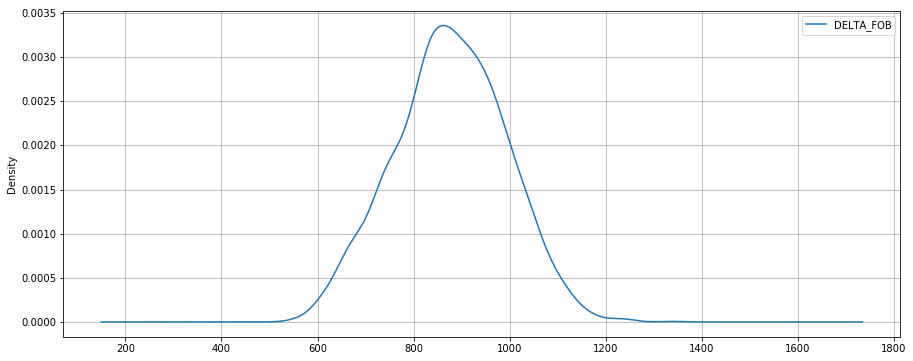

```python
# Your code goes here
output_df.plot.kde(figsize=(15,6))
plt.show()
```

** Answer **  
The most influencial factors on the DELTA FOB are the flown distance (depending on the destination airport TIME_TOTAl), the aircraft weight (MAX_GW parameter) and also the time spent on the different phases of the flight since the consumption is different with respect to those phases.

## Question 2.2

In this question we work on the distributions of `DELTA_FOB` conditionned on `DESTINATION` and (optional) `RUNWAY_LD`

- Plot `DELTA_FOB` distribution conditionned on `DESTINATION` airport and comment.
- (optional) Plot `DELTA_FOB` distribution conditionned on `DESTINATION` airport and `RUNWAY_LD` and comment.

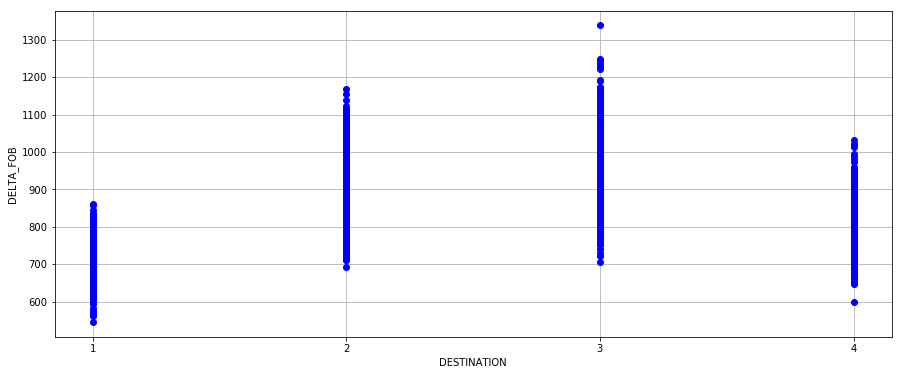

```python
# Your code goes here
dict0 = {
    'ARPT1' : 1,
    'ARPT2' : 2,
    'ARPT3' : 3,
    'ARPT4' : 4,
}
destination = [dict0[x] for x in features_df.DESTINATION.tolist()]
delta_fob = output_df.DELTA_FOB.tolist()

plt.figure(figsize=(15,6))
plt.plot(destination, delta_fob, 'bo')
plt.ylabel('DELTA_FOB')
plt.xlabel('DESTINATION')
plt.xticks([x for x in range(1,5)])
plt.show()
```

** Answer **  
We can assume the distances from this plot: in increasing order with respect to the distance from airport 0 we have airport 1, airport 4, airport 2 and aiport 3.

## Question 2.3

Finally let's work with two important features: the total duration of the flight `TOTAL_TIME` and the quantity of fuel at the beginning of the flight `MAX_FOB`.

- Plot the distributions of the following variables:
  - `MAX_FOB`
  - `TIME_TOTAL`
- Comment these distributions

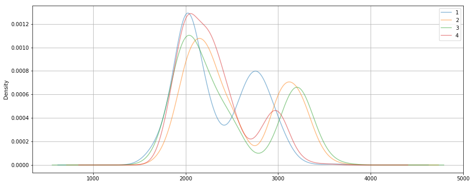

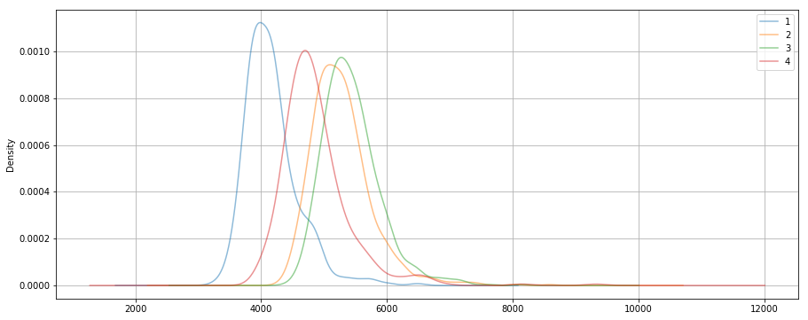

```python
# Your code goes here
features_df[features_df.DESTINATION=='ARPT1'].MAX_FOB.plot.kde(figsize=(15,6), alpha=0.5,label='1')
features_df[features_df.DESTINATION=='ARPT2'].MAX_FOB.plot.kde(figsize=(15,6), alpha=0.5,label='2')
features_df[features_df.DESTINATION=='ARPT3'].MAX_FOB.plot.kde(figsize=(15,6), alpha=0.5,label='3')
features_df[features_df.DESTINATION=='ARPT4'].MAX_FOB.plot.kde(figsize=(15,6), alpha=0.5,label='4')
plt.legend()
plt.show()
features_df[features_df.DESTINATION=='ARPT1'].TIME_TOTAL.plot.kde(figsize=(15,6), alpha=0.5,label='1')
features_df[features_df.DESTINATION=='ARPT2'].TIME_TOTAL.plot.kde(figsize=(15,6), alpha=0.5,label='2')
features_df[features_df.DESTINATION=='ARPT3'].TIME_TOTAL.plot.kde(figsize=(15,6), alpha=0.5,label='3')
features_df[features_df.DESTINATION=='ARPT4'].TIME_TOTAL.plot.kde(figsize=(15,6), alpha=0.5,label='4')
plt.legend()
plt.show()
```

** Answer **  
The plots are coherent with the number of routes we calculated before. We can see the overlapping regions in the first plot which make the first spike a bit difficult to interpret, however the second spike shows separation between airports 1,4 and airports 2,3. Same for the second plot where our hypothesis on the airport to airport distances is confirmed.

# 3 Model DELTA_FOB

We use [sklearn](http://scikit-learn.org/stable/documentation.html) for models.

## Question 3.1

- Scatter plot `TIME_TOTAL` against `DELTA_FOB`.
- Is there any relationship?

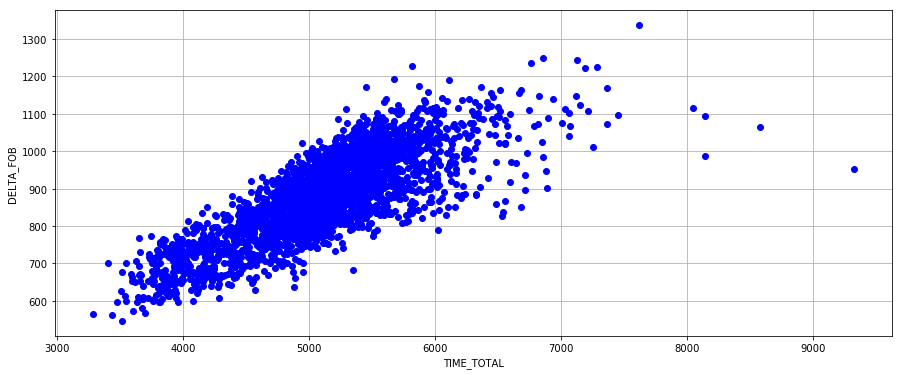

```python
# Your code goes here
destination = features_df.TIME_TOTAL.tolist()
plt.figure(figsize=(15,6))
plt.plot(destination, delta_fob, 'bo')
plt.ylabel('DELTA_FOB')
plt.xlabel('TIME_TOTAL')
plt.show()
```

** Answer **  
We observe some outliers, for example the point at the far right of the plot is not that high in fuel consumption. This can be for example because the aircraft had a long 'taxi phase'. However we can still se a nice blob which confirms that there is an interesting relationship between the 2 parameters.

Let's explore the predictive power of `TIME_TOTAL` on `DELTA_FOB`. Our first model is the following linear regression:

- algorithm: `LinearRegression` from sklearn package `linear_model` ([reference](http://scikit-learn.org/stable/modules/generated/sklearn.linear_model.LinearRegression.html))
- input: `TIME_TOTAL`
- output: `DELTA_FOB`

Follow the code below, in the following questions you will extensively use this template code and adapt it.

## Question 3.2

Comment briefly the results, the following questions can help you:

- What is the score method implemented by sklearn?
- How do you relate it to the mse?
- What is best to interprete the quality of the estimator?

```python
# This is template code for setting up a sklearn regression model

X = features_df[["TIME_TOTAL"]].as_matrix()

y = output_df[["DELTA_FOB"]].as_matrix()

test_size = 0.2
random_state = 42


# Split the features and output in training and test sets
X_train, X_test, y_train, y_test = model_selection.train_test_split(X, y, test_size=test_size, random_state=random_state)

# Create linear regression object
estimator = linear_model.LinearRegression()

# Train the model using the training sets
estimator.fit(X_train, y_train)

# Test the model on tests sets
print("score", estimator.score(X_test, y_test))
```

```
score 0.606144364551
```

** Answer **  
MSE is dependent on the outliers. The sklearn score takes into account the squared error on the prediction, but also the variance in our ground truth data which will diminish the influence of the outliers on the calculation of the score. Hence, the sklearn estimator is more interesting the evaluate if the global tendency of our estimator is good.

## Question 3.3

- Adapt the code above for the following model
  - algorithm: `LinearRegression`
  - input: `TIME_TOTAL`, `MAX_FOB`
  - output: `DELTA_FOB`
- Compare the score with the results of the previous regression
  - is it getting better?
  - which variable has the most predictive power among `TIME_TOTAL` and `MAX_FOB`?

```python
# Your code goes here
# This is template code for setting up a sklearn regression model

X = features_df[["TIME_TOTAL","MAX_FOB"]].as_matrix()

y = output_df[["DELTA_FOB"]].as_matrix()

test_size = 0.2
random_state = 42


# Split the features and output in training and test sets
X_train, X_test, y_train, y_test = model_selection.train_test_split(X, y, test_size=test_size, random_state=random_state)

# Create linear regression object
estimator = linear_model.LinearRegression()

# Train the model using the training sets
estimator.fit(X_train, y_train)

# Test the model on tests sets
print("score", estimator.score(X_test, y_test))
```

```
score 0.708710764451
```

** Answer **  
The result is better since we are taking into account one more variable, we are more precise. If we do this only with MAX_FOB the score is < 0.1, so, as we stated before, TIME_TOTAL has more predictive power for our model than MAX_FOB.

Before moving on and adding more features to our models, let's compare our linear regressions to a simple non-linear model:

- algorithm: `DecisionTreeRegressor` from sklearn package `tree` ([reference](http://scikit-learn.org/stable/modules/generated/sklearn.tree.DecisionTreeRegressor.html))
- input: `TIME_TOTAL`, `MAX_FOB`
- output: `DELTA_FOB`

## Question 3.4

- Adapt the code for the model described above.
- What is the default behavior for `max_depth` parameter?
- With a default behavior, is the score better than with linear regression?
- Split in 10 validation sets and optimize `max_depth` parameter (you can use the template code below)
  - plot `max_depth` parameters against the score
  - why is it not OK to optimize parameters only with train and test sets?
- What attributes can you use to you interprete the tree?

```python
# Your code goes here
# This is template code for setting up a sklearn regression model

X = features_df[["TIME_TOTAL","MAX_FOB"]].as_matrix()

y = output_df[["DELTA_FOB"]].as_matrix()

test_size = 0.2
random_state = 42


# Split the features and output in training and test sets
X_train, X_test, y_train, y_test = model_selection.train_test_split(X, y, test_size=test_size, random_state=random_state)

# Create linear regression object
estimator = tree.DecisionTreeRegressor()

# Train the model using the training sets
estimator.fit(X_train, y_train)

# Test the model on tests sets
print("score", estimator.score(X_test, y_test))
```

```
score 0.58694029603
```

** Answer **  
The default behaviour for max_depth is none, which means there is no limit to the number of questions asked (the only limit is the number of features). We can see that with the default behaviour, the score is less important than with the linear regression model.

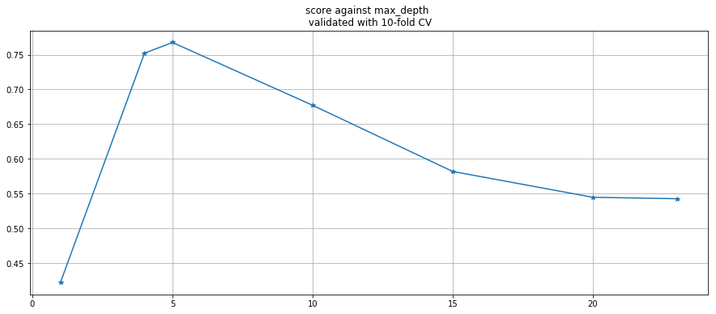

```python
# This is the template code for cross validation, fill in the blanks

max_depths = [1, 4, 5, 10, 15, 20, 23]

kFold = model_selection.KFold(n_splits=10)
scores = []

for max_depth in max_depths:
    estimator.set_params(max_depth=max_depth)
    score = []
    folds = kFold.split(X)
    for fold in folds:
        # Unpack train and test indices
        train, test = fold
        # Split in train and test sets
        X_train, X_test, y_train, y_test = X[train], X[test], y[train], y[test]
        estimator.fit(X_train, y_train)
        score.append(estimator.score(X_test, y_test))
    scores.append(np.mean(score))

plt.figure(figsize=(15,6))
plt.plot(max_depths, scores, marker="*")
plt.title("score against max_depth \n validated with 10-fold CV")
plt.show()
```

```python
estimator.tree_.compute_feature_importances()
```

```
array([ 0.76755289,  0.23244711])
```

** Answer **  
To avoid overfitting, we would need a validation dataset which does not intervene at any moment in the training (not even in the 10 fold validation). Furthermore we get some parameters from the model after the training, for exemple the importance of each feature (here we can see 77% for TIME_TOTAL and 23% for MAX_FOB), the best thresholds chosen to separate the nodes of the tree, etc.

Let's add all the other numeric features.

```python
numeric_features = ['MAX_FOB',
                    'MAX_GW',
                    'TIME_APPROACH',
                    'TIME_CLIMB',
                    'TIME_CRUISE',
                    'TIME_DESCENT',
                    'TIME_ENG START',
                    'TIME_FINAL APP',
                    'TIME_FLARE',
                    'TIME_GO AROUND',
                    'TIME_INIT CLIMB',
                    'TIME_LANDING',
                    'TIME_LVL CHANGE',
                    'TIME_TAKE OFF',
                    'TIME_TAXI IN',
                    'TIME_TAXI OUT',
                    'TIME_TOUCH N GO',
                    'TIME_TOTAL']
```

## Question 3.5

We use the `StandardScaler` from sklearn `preprocessing` package ([reference](http://scikit-learn.org/stable/modules/preprocessing.html)).

- Give one reason for rescaling the features before doing regularized regression
- Fill in the blanks in the code below and observe the results printed out
- Why the first feature of `X_test_transformed` does not have a std of 1?

```python
# This is the template code for rescaling the features, fill in the blanks
X = features_df[numeric_features].as_matrix()

y = output_df[["DELTA_FOB"]].as_matrix()

test_size = 0.2
random_state = 42
X_train, X_test, y_train, y_test = model_selection.train_test_split(X, y, test_size=test_size, random_state=random_state)


scaler = preprocessing.StandardScaler()

scaler.fit(X_train,y_train) # Fill in the blanks

X_train_transformed = scaler.transform(X_train) # Fill in the blanks
X_test_transformed = scaler.transform(X_test) # Fill in the blanks

print("X_train_transformed first feature,", "mean:", X_train_transformed[:, 0].mean(), "std:", X_train_transformed[:, 0].std())
print("X_test_transformed first feature,", "mean:", X_test_transformed[:, 0].mean(), "std:", X_test_transformed[:, 0].std())
```

```
X_train_transformed first feature, mean: -1.36892068335e-16 std: 1.0
X_test_transformed first feature, mean: 0.0510960710978 std: 1.03838428734
```

** Answer **  
If our features are unscaled, meaning have very different means and variances, the model might consider some more important than the others. Since we want to consider all the features as equally important, we need to perform the rescales to have means and stds of the same order of magnitude. The scaler transforns the train data into a gaussian distribution of 0 mean (e-16 here) and unit variance. Since the model was trained from X_train (fit() function) we cannot expect a perfect result of the transform function on X_test: this explains why the std is not perfectly a unit but a close value to 1.

The last question of this part focus on regularized linear regression.

- algorithm: `Ridge` for sklearn package `linear_model` ([reference](http://scikit-learn.org/stable/modules/generated/sklearn.linear_model.Ridge.html))
- input: `numeric_features` of `features_df`
- output: `DELTA_FOB`

## Question 3.6

- Use the previous template codes and adapt it to set up the models described above and rescale the features
- Split in validation sets and optimize `alpha` parameter
- Interprete the coefficients of your best estimator

```python
# Create linear regression object
estimator = linear_model.Ridge()

# Train the model using the training sets
estimator.fit(X_train_transformed, y_train)

# Test the model on tests sets
print("score", estimator.score(X_test_transformed, y_test))
```

```
score 0.919968073452
```

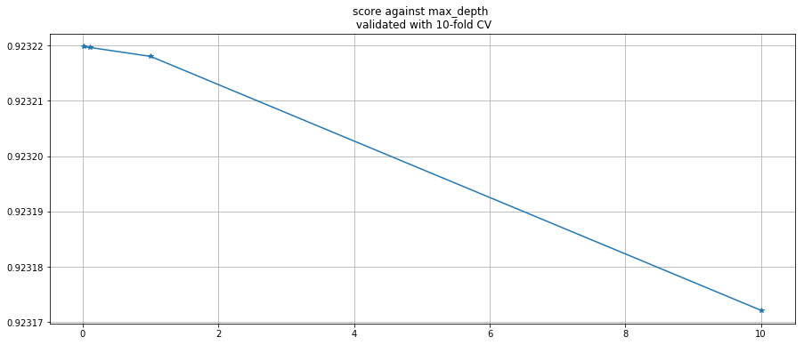

```
[0.92321979163830936, 0.9232196593233748, 0.92321803120266954, 0.92317213197656611]
```

```python
# This is the template code for cross validation, fill in the blanks

alphas = [0.01, 0.1, 1.0, 10]

kFold = model_selection.KFold(n_splits=10)
scores = []

for alpha in alphas:
    estimator.set_params(alpha=alpha)
    score = []
    folds = kFold.split(X)
    for fold in folds:
        # Unpack train and test indices
        train, test = fold
        # Split in train and test sets
        X_train, X_test, y_train, y_test = X[train], X[test], y[train], y[test]
        scaler = preprocessing.StandardScaler()
        scaler.fit(X_train,y_train)
        X_train_transformed = scaler.transform(X_train)
        X_test_transformed = scaler.transform(X_test)
        estimator.fit(X_train_transformed, y_train)
        score.append(estimator.score(X_test_transformed, y_test))
    scores.append(np.mean(score))

plt.figure(figsize=(15,6))
plt.plot(alphas, scores, marker="*")
plt.title("score against max_depth \n validated with 10-fold CV")
plt.show()
print(scores)
```

```python
#For alpha = 0.01
print(estimator.coef_[0])
```

```
[-43.0756129    6.9400853   10.32969808  15.07226381  61.93263337
  21.79498461 -19.52879199   3.70709714  -1.02951046   3.64886883
   2.21086266  -5.34431002   6.51704231   0.91314432  -4.74723878
  -1.71496041   0.          61.90009157]
```

# 4 Feature engineering & model delta_fob for each phase

We will add a lot of information with engine-related time series:

- `TORQ1_C`, `TORQ2_C`
- `NL1`, `NL2`
- `NH1_C`, `NH2_C`

## Visualization of engine-related time series for one flight

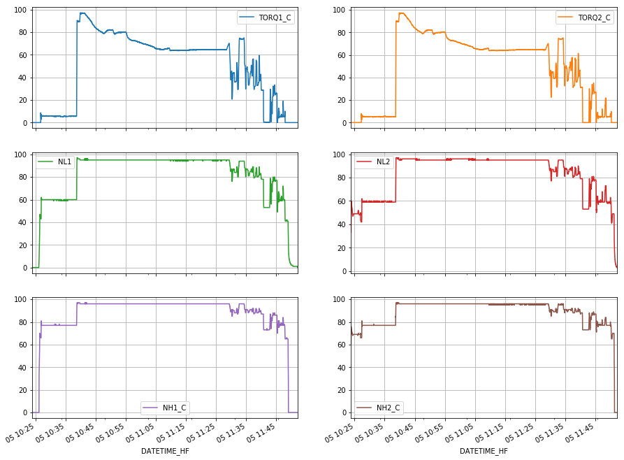

```python
# Five an alias to dfs[0]
df = dfs[0]

engine_features = ['TORQ1_C', 'TORQ2_C',
                  'NL1', 'NL2',
                  'NH1_C', 'NH2_C']

df[engine_features].plot(subplots=True, layout=(3, 2), figsize=(15, 12));
```

## Question 4.1

We will extract few numbers out of each phase for all engine variables (`TORQ1_C`, `TORQ2_C`, `NL1`, `NL2`, `NH1_C`, `NH2_C`)

- Feature engineering
  - get `TORQ1_C` of one phase of one flight, do a linear regression by index and plot the result
  - is it OK to resume the signal by a straight line? what other features would you add?

```python
df.FLIGHT_PHASE.value_counts().keys()
```

[output not shown]

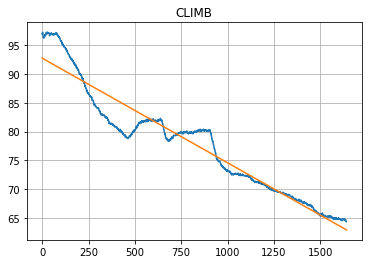

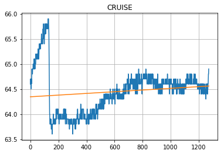

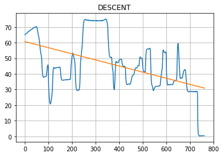

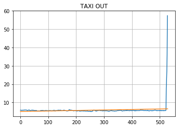

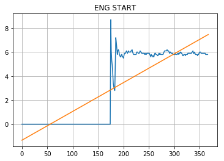

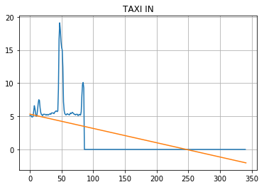

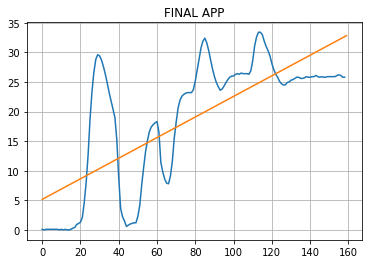

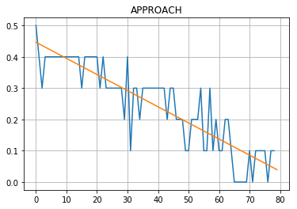

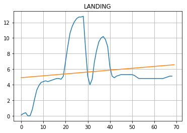

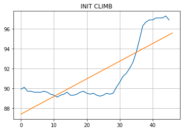

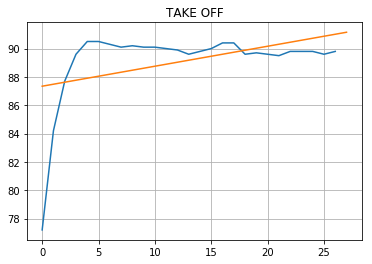

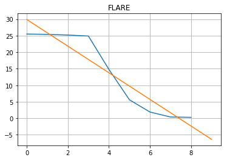

```python
# Your code goes here
#df[df.FLIGHT_PHASE=="CLIMB"].TORQ1_C.plot()

for phase in df.FLIGHT_PHASE.value_counts().keys():
    y = df[df.FLIGHT_PHASE==phase].TORQ1_C.tolist()
    x = [x for x in range(len(y))]

    # Create linear regression object
    estimator = linear_model.LinearRegression()

    # Train the model using the training sets
    estimator.fit(np.array(x).reshape(-1,1), np.array(y).reshape(-1,1))

    coefs = [estimator.coef_[0][0], estimator.intercept_[0]]
    plt.plot(x,y)
    plt.title(phase)
    plt.plot([0,len(x)],[coefs[1], coefs[0]*len(x)+coefs[1]])
    plt.show()
```

** Answer **  
We can see that approximateing only with one line is not at all suitable for most of the phases.

These features have been created for you in the `features2_df` dataframe.

## Recap features2_df

```python
file_features2 = BASE_DIR + "features2_df.pkl"

features2_df = pd.read_pickle(file_features2)

numeric_features2 = list(features2_df.columns.values)
numeric_features2.remove("DATE_HF")
numeric_features2.remove("ORIGIN")
numeric_features2.remove("DESTINATION")
numeric_features2.remove("RUNWAY_TO")
numeric_features2.remove("RUNWAY_LD")

features2_df.describe()
```

|  | MAX_FOB | MAX_GW | TIME_APPROACH | TIME_CLIMB | TIME_CRUISE | TIME_DESCENT | TIME_ENG START | TIME_FINAL APP | TIME_FLARE | TIME_GO AROUND | TIME_INIT CLIMB | ... | GO AROUND_NL2_sum | GO AROUND_NH1_C_intercept | GO AROUND_NH1_C_slope | GO AROUND_NH1_C_mean | GO AROUND_NH1_C_median | GO AROUND_NH1_C_sum | GO AROUND_NH2_C_intercept | GO AROUND_NH2_C_slope | GO AROUND_NH2_C_mean | GO AROUND_NH2_C_median | GO AROUND_NH2_C_sum |
| --- | --- | --- | --- | --- | --- | --- | --- | --- | --- | --- | --- | --- | --- | --- | --- | --- | --- | --- | --- | --- | --- | --- | --- |
| count | 2742.000000 | 2742.000000 | 2742.000000 | 2742.000000 | 2742.000000 | 2742.000000 | 2742.000000 | 2742.000000 | 2742.000000 | 2742.000000 | 2742.000000 | ... | 2742.000000 | 2742.000000 | 2742.000000 | 2742.000000 | 2742.000000 | 2742.000000 | 2742.000000 | 2742.000000 | 2742.000000 | 2742.000000 | 2742.000000 |
| mean | 2439.663020 | 20495.557987 | 143.109044 | 1190.589351 | 1568.312181 | 745.985412 | 496.062728 | 193.513494 | 8.628009 | 3.467177 | 48.092268 | ... | 293.386214 | 0.620627 | -0.000196 | 0.592350 | 0.592633 | 312.923414 | 0.617573 | -0.000199 | 0.588722 | 0.589351 | 310.746900 |
| std | 482.857964 | 1161.616565 | 94.942888 | 258.253887 | 581.133001 | 182.289871 | 307.850561 | 78.275612 | 2.584759 | 54.190701 | 11.540036 | ... | 4601.951816 | 7.637718 | 0.003073 | 7.289696 | 7.294202 | 4909.082612 | 7.600159 | 0.003068 | 7.244929 | 7.253416 | 4868.284591 |
| min | 1616.000000 | 17300.000000 | 1.000000 | 85.000000 | 9.000000 | 230.000000 | 127.000000 | 65.000000 | 1.000000 | 0.000000 | 17.000000 | ... | 0.000000 | 0.000000 | -0.092567 | 0.000000 | 0.000000 | 0.000000 | 0.000000 | -0.089114 | 0.000000 | 0.000000 | 0.000000 |
| 25% | 2028.000000 | 19640.000000 | 83.000000 | 1012.000000 | 1102.250000 | 613.000000 | 322.000000 | 143.000000 | 7.000000 | 0.000000 | 40.000000 | ... | 0.000000 | 0.000000 | 0.000000 | 0.000000 | 0.000000 | 0.000000 | 0.000000 | 0.000000 | 0.000000 | 0.000000 | 0.000000 |
| 50% | 2243.000000 | 20540.000000 | 126.000000 | 1160.000000 | 1687.500000 | 715.000000 | 411.000000 | 174.000000 | 8.000000 | 0.000000 | 47.000000 | ... | 0.000000 | 0.000000 | 0.000000 | 0.000000 | 0.000000 | 0.000000 | 0.000000 | 0.000000 | 0.000000 | 0.000000 | 0.000000 |
| 75% | 2922.000000 | 21400.000000 | 187.000000 | 1340.000000 | 1995.750000 | 854.000000 | 566.000000 | 216.000000 | 10.000000 | 0.000000 | 54.000000 | ... | 0.000000 | 0.000000 | 0.000000 | 0.000000 | 0.000000 | 0.000000 | 0.000000 | 0.000000 | 0.000000 | 0.000000 | 0.000000 |
| max | 3732.000000 | 23440.000000 | 1560.000000 | 2445.000000 | 3467.000000 | 1892.000000 | 5142.000000 | 748.000000 | 24.000000 | 1715.000000 | 133.000000 | ... | 147688.000000 | 98.646564 | 0.000000 | 94.434783 | 97.000000 | 156919.000000 | 97.793829 | 0.000000 | 93.739130 | 96.000000 | 154950.000000 |

8 rows × 468 columns

Let's be more ambitious and predict the fuel consumed by each phase. It would help a lot more to model the fuel consumption behavior for each phase when it will come to interpretation. The dataframe `output2_df` containing the fuel consumed by each phase for each flight has been created for you.

```python
file_output2 = BASE_DIR + "output2_df.pkl"
output2_df = pd.read_pickle(file_output2)

output2_df.describe()
```

|  | APPROACH | CLIMB | CRUISE | DESCENT | ENG START | FINAL APP | FLARE | GO AROUND | INIT CLIMB | LANDING | LVL CHANGE | TAKE OFF | TAXI IN | TAXI OUT | TOUCH N GO |
| --- | --- | --- | --- | --- | --- | --- | --- | --- | --- | --- | --- | --- | --- | --- | --- |
| count | 2742.000000 | 2742.000000 | 2742.000000 | 2742.000000 | 2742.000000 | 2742.000000 | 2742.000000 | 2742.000000 | 2742.000000 | 2742.000000 | 2742.000000 | 2742.000000 | 2742.000000 | 2742.000000 | 2742.000000 |
| mean | 44.630197 | 245.240700 | 293.458789 | 148.687819 | 21.590810 | 43.513494 | 3.267688 | 0.868709 | 42.369803 | 48.817651 | 2.668855 | 24.814004 | 55.407002 | 37.649161 | 0.024799 |
| std | 31.565958 | 57.213462 | 115.312441 | 50.315759 | 24.553695 | 24.024636 | 2.862884 | 12.350451 | 15.094655 | 27.173412 | 15.723734 | 8.199072 | 22.695547 | 16.681081 | 1.298599 |
| min | 0.000000 | 54.000000 | 2.000000 | 16.000000 | 4.000000 | 4.000000 | 0.000000 | 0.000000 | 2.000000 | 2.000000 | 0.000000 | 2.000000 | 10.000000 | 8.000000 | 0.000000 |
| 25% | 22.000000 | 202.000000 | 204.000000 | 116.000000 | 14.000000 | 28.000000 | 2.000000 | 0.000000 | 32.000000 | 22.000000 | 0.000000 | 18.000000 | 38.000000 | 26.000000 | 0.000000 |
| 50% | 42.000000 | 240.000000 | 306.000000 | 154.000000 | 18.000000 | 42.000000 | 2.000000 | 0.000000 | 42.000000 | 52.000000 | 0.000000 | 24.000000 | 52.000000 | 34.000000 | 0.000000 |
| 75% | 62.000000 | 282.000000 | 376.000000 | 180.000000 | 26.000000 | 56.000000 | 4.000000 | 0.000000 | 54.000000 | 70.000000 | 0.000000 | 30.000000 | 70.000000 | 44.000000 | 0.000000 |
| max | 712.000000 | 512.000000 | 754.000000 | 416.000000 | 1170.000000 | 410.000000 | 24.000000 | 312.000000 | 86.000000 | 120.000000 | 344.000000 | 82.000000 | 154.000000 | 126.000000 | 68.000000 |

## Question 4.3

In this question we make use of `output2_df` to determine the phase that consumes the most fuel per second in average.

- What flight phase consumes the most in average?
- What flight phase consumes the most per second in average?

```python
# This is template code to extract the phases durations out of features_df and rename the columns to make them identical to output2_df

phases_durations_df = features2_df[["TIME_" + fp for fp in flight_phases]]
phases_durations_df.columns = flight_phases
phases_durations_df.head()
```

|  | APPROACH | CLIMB | CRUISE | DESCENT | ENG START | FINAL APP | FLARE | INIT CLIMB | LANDING | TAKE OFF | TAXI IN | TAXI OUT | TOUCH N GO | LVL CHANGE | GO AROUND |
| --- | --- | --- | --- | --- | --- | --- | --- | --- | --- | --- | --- | --- | --- | --- | --- |
| 0 | 106 | 857 | 1123 | 762 | 705 | 203 | 12 | 49 | 36 | 26 | 222 | 295 | 0 | 0 | 0 |
| 1 | 219 | 1129 | 649 | 933 | 174 | 151 | 7 | 39 | 53 | 22 | 219 | 225 | 0 | 0 | 0 |
| 2 | 152 | 1139 | 2418 | 366 | 354 | 188 | 10 | 47 | 36 | 23 | 238 | 215 | 0 | 323 | 0 |
| 3 | 32 | 749 | 2676 | 619 | 249 | 243 | 9 | 34 | 32 | 21 | 217 | 182 | 0 | 0 | 0 |
| 4 | 62 | 1038 | 1040 | 1210 | 302 | 161 | 5 | 34 | 24 | 27 | 506 | 1016 | 0 | 0 | 0 |

```python
# Your code goes here
conspersec = output2_df.div(phases_durations_df)
conspersec.describe()
```

|  | APPROACH | CLIMB | CRUISE | DESCENT | ENG START | FINAL APP | FLARE | GO AROUND | INIT CLIMB | LANDING | LVL CHANGE | TAKE OFF | TAXI IN | TAXI OUT | TOUCH N GO |
| --- | --- | --- | --- | --- | --- | --- | --- | --- | --- | --- | --- | --- | --- | --- | --- |
| count | 2742.000000 | 2742.000000 | 2742.000000 | 2742.000000 | 2742.000000 | 2742.000000 | 2742.000000 | 18.000000 | 2742.000000 | 2742.000000 | 160.000000 | 2742.000000 | 2742.000000 | 2742.000000 | 1.00000 |
| mean | 0.360921 | 0.207534 | 0.187395 | 0.201353 | 0.046231 | 0.236815 | 0.374319 | 0.321618 | 0.889580 | 1.134456 | 0.357820 | 0.993857 | 0.214964 | 0.120234 | 0.60177 |
| std | 0.275525 | 0.031777 | 0.027114 | 0.060765 | 0.040596 | 0.119249 | 0.310158 | 0.157507 | 0.271189 | 0.829859 | 0.345849 | 0.338416 | 0.110590 | 0.043311 | NaN |
| min | 0.000000 | 0.139605 | 0.059406 | 0.038929 | 0.014354 | 0.030303 | 0.000000 | 0.165323 | 0.055556 | 0.050633 | 0.000000 | 0.100000 | 0.039088 | 0.046512 | 0.60177 |
| 25% | 0.179436 | 0.183027 | 0.170264 | 0.145312 | 0.034858 | 0.140704 | 0.200000 | 0.225840 | 0.690909 | 0.486816 | 0.169789 | 0.750000 | 0.133419 | 0.091893 | 0.60177 |
| 50% | 0.299491 | 0.204301 | 0.187135 | 0.213414 | 0.043011 | 0.222851 | 0.307692 | 0.262628 | 0.916667 | 0.925926 | 0.284832 | 0.962963 | 0.190114 | 0.109957 | 0.60177 |
| 75% | 0.451091 | 0.229735 | 0.203000 | 0.247382 | 0.053599 | 0.307692 | 0.500000 | 0.376276 | 1.086646 | 1.623512 | 0.407596 | 1.217391 | 0.274636 | 0.137566 | 0.60177 |
| max | 2.736842 | 0.635294 | 0.345098 | 0.448649 | 2.024221 | 0.823529 | 2.000000 | 0.782609 | 1.640000 | 4.181818 | 2.506667 | 2.000000 | 0.826347 | 0.559140 | 0.60177 |

** Answer **  
CRUISE phase consumes the most in average. LANDING phase consumes the most per second in average.

## Question 4.4

This last question aims to let you work with `features2_df` and `output2_df`. You can make use of any pieces of code we have worked with so far: especially to set up your models, rescale the features, optimize and validate your models... The expected outcome is to explain to the company what parameters influence the most the fuel consumption of their fleet and give them advice to consume less.

- The algorithm:
  - algorithm: you choose
  - input: `features2_df`, output: `output2_df`
- Interprete the coefficients, explain the causes of fuel consumption for each phase, give adive to the company to consume less in their following flights

```python
# Your code goes here
```